# 「多群の平均値の比較」補足資料

大学入試センター研究開発部 寺尾 尚大

2021/04/05

この資料は，月刊「臨床栄養」の第138巻4号「回答しやすく・分析しやすい 業務に活かせる！アンケート調査のキホンと応用」の第13回「多群の平均値の比較」で用いたデータ例について，読者の理解をさらに深めるために作成されたものです。

# 1要因被験者間分散分析

群平均どうしが近いところにあるケース (a) と，群平均どうしが離れているケース (b) として使用したデータの概要を，それぞれ示します。

## 群平均どうしが近いケース

### 分析に使用したデータ

分析に使用したのは240名分のデータですが，ここでは6名分のデータを示しています。

- ageは年齢層を表す（ヤング群：young，中年群：middle，シニア群：senior)
- scoreは給食への満足度得点を表す

|  | age | score |
| --- | --- | --- |
| 1 | young | 59 |
| 2 | young | 61 |
| 81 | middle | 83 |
| 82 | middle | 52 |
| 161 | senior | 60 |
| 162 | senior | 57 |

### 記述統計量

#### 全体

|  | 人数 | 平均 | 標準偏差 | 中央値 | 最小値 | 最大値 | 範囲 | 歪度 | 尖度 |
| --- | --- | --- | --- | --- | --- | --- | --- | --- | --- |
| score | 240 | 54.913 | 8.004 | 54 | 32 | 83 | 51 | 0.183 | 0.248 |

#### 年代群ごと

|  | 人数 | 平均 | 標準偏差 | 中央値 | 最小値 | 最大値 | 範囲 | 歪度 | 尖度 |
| --- | --- | --- | --- | --- | --- | --- | --- | --- | --- |
| young | 80 | 54.513 | 7.707 | 55.0 | 34 | 71 | 37 | -0.351 | -0.044 |
| middle | 80 | 55.325 | 8.169 | 53.0 | 41 | 83 | 42 | 0.747 | 0.412 |
| senior | 80 | 54.900 | 8.207 | 54.5 | 32 | 74 | 42 | 0.048 | -0.064 |

### ヒストグラム

#### 全体

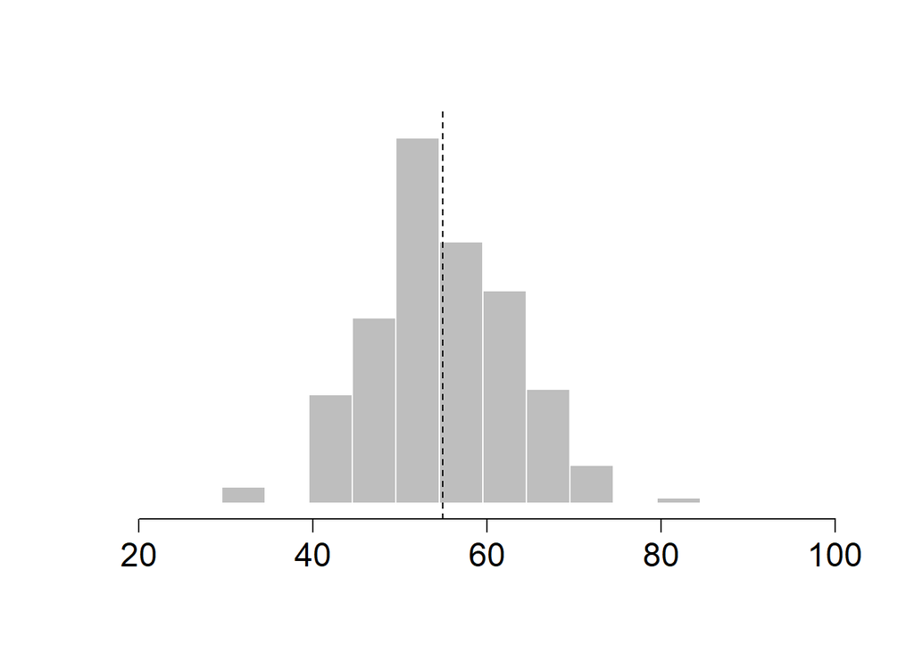

#### 年代群ごと

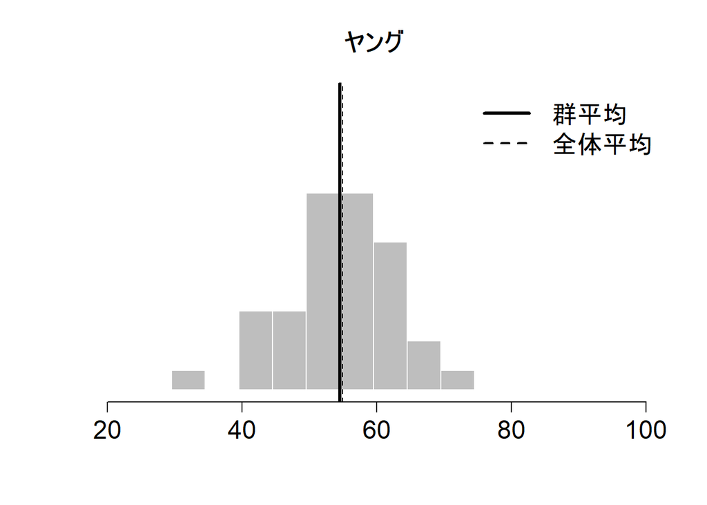

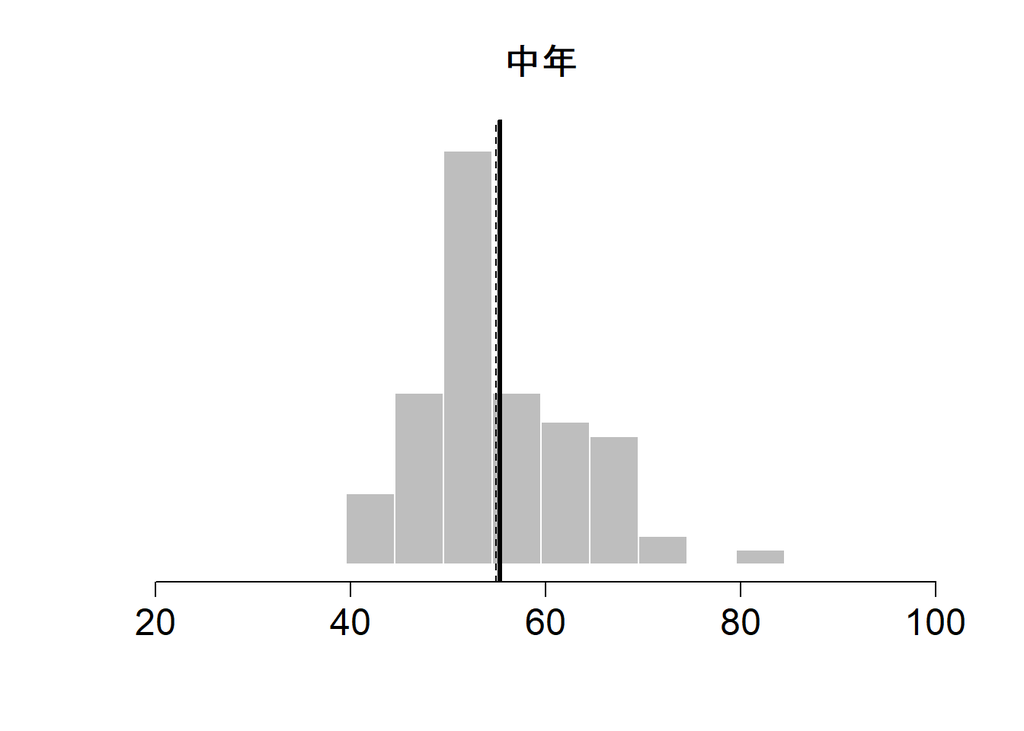

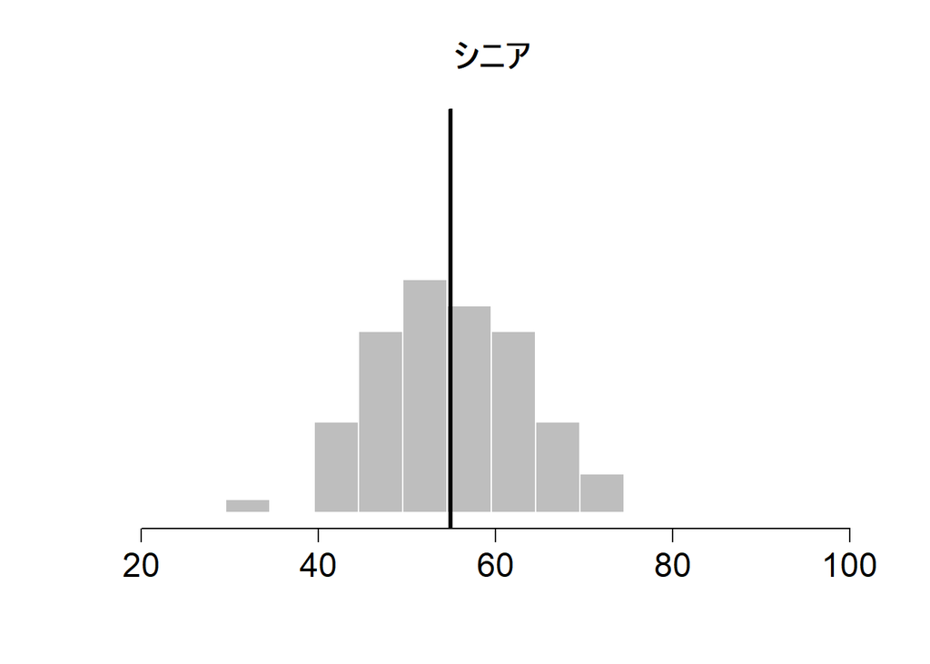

### 分散分析の結果

- ageは参加者の年代群に関する平方和（群間平方和），Residualsは群内平方和を表す
- DfはF分布の自由度を表す
  - 群間平方和の自由度は群の数-1(3-1=2)
  - 群内平方和の自由度はサンプルサイズ-群の数(240-3=237)
- Sum Sqは平方和の値を表す
- Mean Sqは平均平方であり，平方和を自由度で割った値
- F valueはF統計量 (群間平均平方/群内平均平方)
- Pr(>F) はp値

Analysis of Variance Model

|  | Df | Sum Sq | Mean Sq | F value | Pr(>F) |
| --- | --- | --- | --- | --- | --- |
| **age** | 2 | 26.4 | 13.2 | 0.205 | 0.815 |
| **Residuals** | 237 | 15285 | 64.5 |  |  |

このケースでは，F統計量が小さく，p値は0.05を上回っているため，帰無仮説を保持する。

## 群間に平均値差があるケース

### 分析に使用したデータ

[output not shown]

### 記述統計量

#### 全体

|  | 人数 | 平均 | 標準偏差 | 中央値 | 最小値 | 最大値 | 範囲 | 歪度 | 尖度 |
| --- | --- | --- | --- | --- | --- | --- | --- | --- | --- |
| score | 240 | 54.725 | 9.623 | 55 | 23 | 77 | 54 | -0.258 | -0.222 |

#### 年代群ごと

|  | 人数 | 平均 | 標準偏差 | 中央値 | 最小値 | 最大値 | 範囲 | 歪度 | 尖度 |
| --- | --- | --- | --- | --- | --- | --- | --- | --- | --- |
| young | 80 | 48.812 | 9.484 | 48.5 | 23 | 70 | 47 | -0.162 | -0.555 |
| middle | 80 | 55.950 | 8.271 | 56.0 | 37 | 77 | 40 | 0.092 | -0.522 |
| senior | 80 | 59.413 | 7.914 | 60.0 | 42 | 76 | 34 | -0.091 | -0.879 |

### ヒストグラム

#### 全体

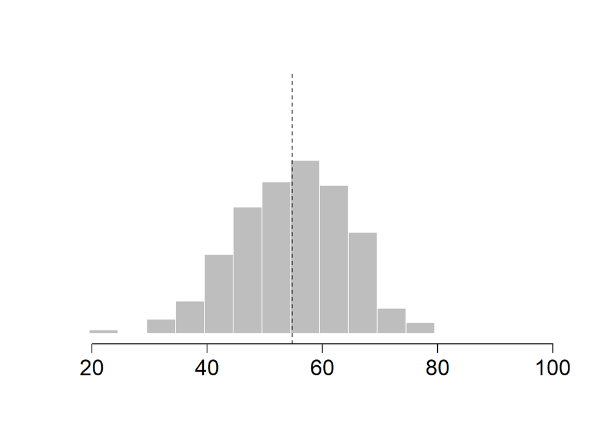

#### 年代群ごと

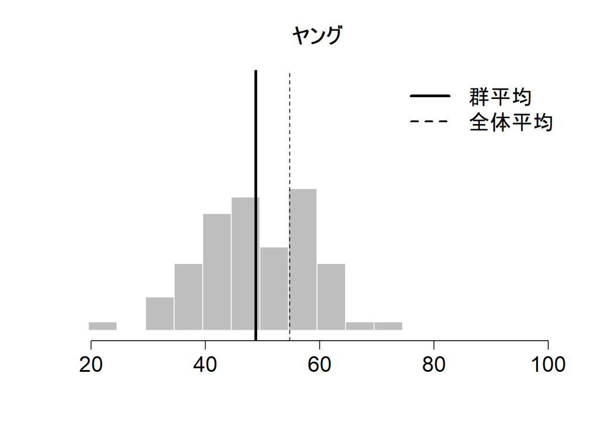

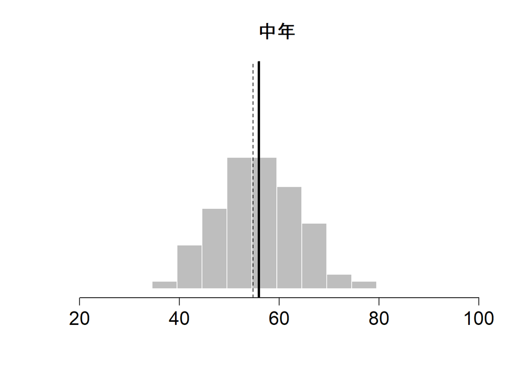

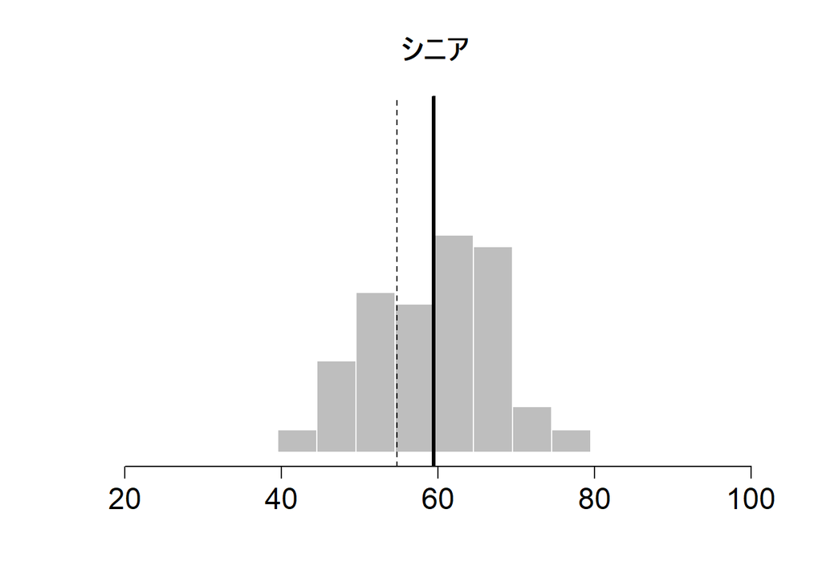

### 分散分析の結果

- ageは参加者の年代群に関する平方和（群間平方和），Residualsは群内平方和を表す
- DfはF分布の自由度を表す
  - 群間平方和の自由度は群の数-1(3-1=2)
  - 群内平方和の自由度はサンプルサイズ-群の数(240-3=237)
- Sum Sqは平方和の値を表す
- Mean Sqは平均平方であり，平方和を自由度で割った値
- F valueはF統計量 (群間平均平方/群内平均平方)
- Pr(>F) はp値

Analysis of Variance Model

|  | Df | Sum Sq | Mean Sq | F value | Pr(>F) |
| --- | --- | --- | --- | --- | --- |
| **age** | 2 | 4674 | 2337 | 31.7 | 6.16e-13 |
| **Residuals** | 237 | 17457 | 73.7 |  |  |

このケースでは，F統計量が大きく，p値は0.05を下回っているため，帰無仮説を棄却する。

# 2要因分散分析（効果検証デザイン）

## (a) 主効果なし・交互作用なしのケース

### 分析に使用したデータ

分析に使用したのは200名分のデータですが，ここでは6名分のデータを示しています。

- groupは群の違いを表す（実験群：exp，対照群：ctl）
- pre, postはそれぞれれ事前・事後の理解度得点を表す

|  | group | pre | post |
| --- | --- | --- | --- |
| 1 | exp | 60 | 63 |
| 2 | exp | 44 | 53 |
| 3 | exp | 55 | 60 |
| 101 | ctl | 52 | 33 |
| 102 | ctl | 43 | 55 |
| 103 | ctl | 48 | 57 |

### 教育プログラム実施前の得点の記述統計量

|  | 人数 | 平均 | 標準偏差 | 中央値 | 最小値 | 最大値 | 範囲 | 歪度 | 尖度 |
| --- | --- | --- | --- | --- | --- | --- | --- | --- | --- |
| ctl | 100 | 49.14 | 9.894 | 49 | 27 | 71 | 44 | -0.055 | -0.609 |
| exp | 100 | 49.41 | 10.783 | 50 | 25 | 73 | 48 | -0.033 | -0.472 |

### 教育プログラム実施後の得点の記述統計量

|  | 人数 | 平均 | 標準偏差 | 中央値 | 最小値 | 最大値 | 範囲 | 歪度 | 尖度 |
| --- | --- | --- | --- | --- | --- | --- | --- | --- | --- |
| ctl | 100 | 49.61 | 9.954 | 49.0 | 28 | 75 | 47 | 0.127 | -0.236 |
| exp | 100 | 50.34 | 11.573 | 50.5 | 19 | 79 | 60 | -0.168 | -0.238 |

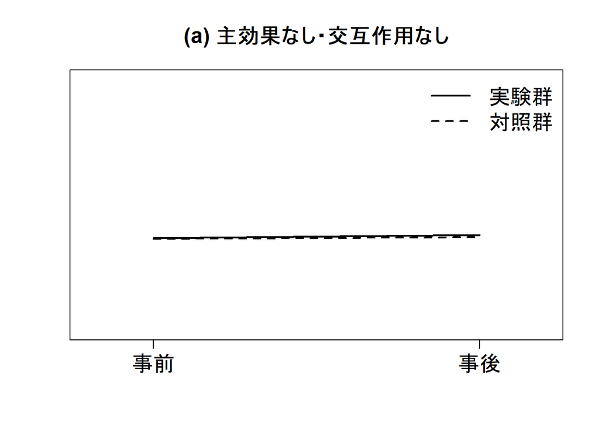

### 分散分析の結果

- groupは群の主効果に関する結果，prepostは調査時期の主効果に関する結果，group:prepostは交互作用効果に関する結果を表す
- Sum Sqは平方和を表す
- num Dfは検討している要因の平方和の自由度を表す (F統計量の分子部分の自由度)
  - group, prepostの平方和の自由度は群の数-1(2-1=1)
  - group:prepostの平方和の自由度は，groupの自由度×prepostの自由度 (1×1=1)
- Error SSは，その要因を検討するときに使うF統計量の分母の平方和を表す
  - 被験者間要因について検討するときは，群内平方和を用いる
  - 被験者内要因が含まれるときは，個人内平方和を用いる
- den DfはError SSの自由度 (F統計量の分母部分の自由度)
- F valueはF統計量 (その要因の平均平方/Error SS関連の平均平方)
- Pr(>F) はp値

```
##
## Univariate Type II Repeated-Measures ANOVA Assuming Sphericity
##
##               Sum Sq num Df Error SS den Df   F value Pr(>F)
## (Intercept)   985056      1    30462    198 6402.8212 <2e-16 ***
## group             25      1    30462    198    0.1625 0.6873
## prepost           49      1    13809    198    0.7026 0.4029
## group:prepost      5      1    13809    198    0.0759 0.7833
## ---
## Signif. codes:  0 '***' 0.001 '**' 0.01 '*' 0.05 '.' 0.1 ' ' 1
```

## (b) 群の主効果のみあり

### 分析に使用したデータ

|  | group | pre | post |
| --- | --- | --- | --- |
| 1 | exp | 79 | 89 |
| 2 | exp | 86 | 78 |
| 3 | exp | 70 | 49 |
| 101 | ctl | 39 | 36 |
| 102 | ctl | 69 | 50 |
| 103 | ctl | 59 | 61 |

### 教育プログラム実施前の得点の記述統計量

|  | 人数 | 平均 | 標準偏差 | 中央値 | 最小値 | 最大値 | 範囲 | 歪度 | 尖度 |
| --- | --- | --- | --- | --- | --- | --- | --- | --- | --- |
| ctl | 100 | 50.85 | 9.759 | 52.5 | 26 | 76 | 50 | -0.116 | -0.254 |
| exp | 100 | 72.99 | 9.770 | 73.0 | 49 | 92 | 43 | -0.297 | -0.665 |

### 教育プログラム実施後の得点の記述統計量

|  | 人数 | 平均 | 標準偏差 | 中央値 | 最小値 | 最大値 | 範囲 | 歪度 | 尖度 |
| --- | --- | --- | --- | --- | --- | --- | --- | --- | --- |
| ctl | 100 | 49.65 | 9.245 | 50.5 | 23 | 69 | 46 | -0.263 | -0.069 |
| exp | 100 | 73.32 | 10.545 | 73.5 | 49 | 98 | 49 | 0.013 | -0.231 |

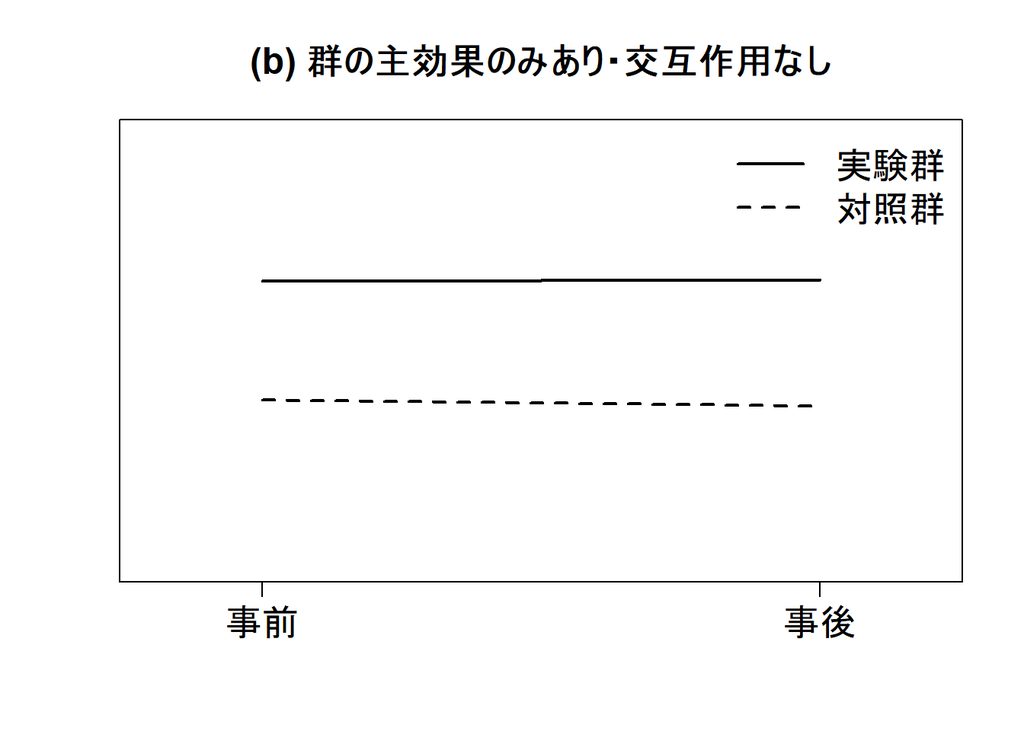

### 分散分析の結果

```
##
## Univariate Type II Repeated-Measures ANOVA Assuming Sphericity
##
##                Sum Sq num Df Error SS den Df    F value Pr(>F)
## (Intercept)   1522879      1    26190    198 11513.0919 <2e-16 ***
## group           52464      1    26190    198   396.6314 <2e-16 ***
## prepost            19      1    12156    198     0.3082 0.5794
## group:prepost      59      1    12156    198     0.9532 0.3301
## ---
## Signif. codes:  0 '***' 0.001 '**' 0.01 '*' 0.05 '.' 0.1 ' ' 1
```

## (c) 調査時期の主効果のみあり

### 分析に使用したデータ

|  | group | pre | post |
| --- | --- | --- | --- |
| 1 | exp | 51 | 83 |
| 2 | exp | 47 | 77 |
| 3 | exp | 38 | 65 |
| 101 | ctl | 35 | 65 |
| 102 | ctl | 54 | 81 |
| 103 | ctl | 34 | 51 |

### 教育プログラム実施前の得点の記述統計量

|  | 人数 | 平均 | 標準偏差 | 中央値 | 最小値 | 最大値 | 範囲 | 歪度 | 尖度 |
| --- | --- | --- | --- | --- | --- | --- | --- | --- | --- |
| ctl | 100 | 51.85 | 10.572 | 52 | 34 | 80 | 46 | 0.411 | -0.225 |
| exp | 100 | 50.69 | 10.222 | 51 | 23 | 71 | 48 | -0.226 | -0.374 |

### 教育プログラム実施後の得点の記述統計量

|  | 人数 | 平均 | 標準偏差 | 中央値 | 最小値 | 最大値 | 範囲 | 歪度 | 尖度 |
| --- | --- | --- | --- | --- | --- | --- | --- | --- | --- |
| ctl | 100 | 76.28 | 11.425 | 77 | 51 | 104 | 53 | -0.050 | -0.367 |
| exp | 100 | 75.99 | 10.282 | 76 | 51 | 100 | 49 | 0.107 | -0.145 |

```
##       pre  post
## ctl 51.85 76.28
## exp 50.69 75.99
```

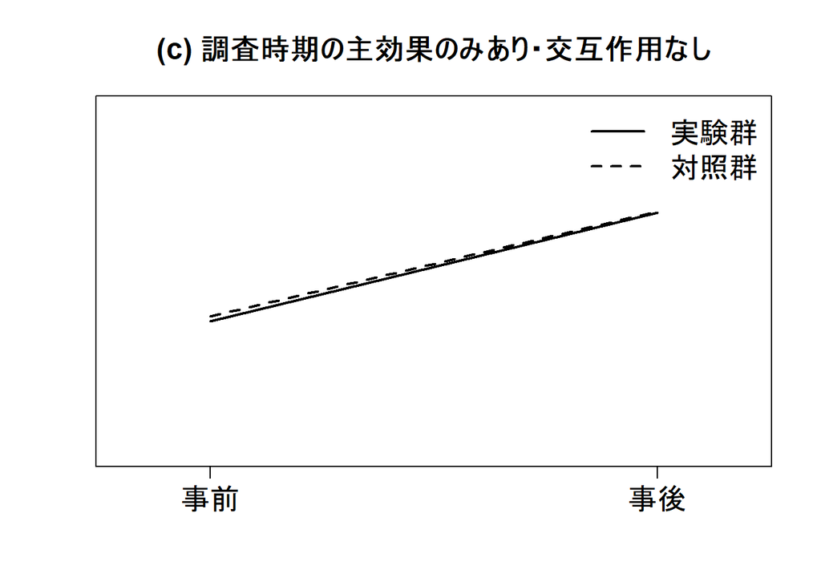

### 分散分析の結果

```
##
## Univariate Type II Repeated-Measures ANOVA Assuming Sphericity
##
##                Sum Sq num Df Error SS den Df   F value Pr(>F)
## (Intercept)   1623203      1    32627    198 9850.7020 <2e-16 ***
## group              53      1    32627    198    0.3190 0.5729
## prepost         61827      1    12173    198 1005.6648 <2e-16 ***
## group:prepost      19      1    12173    198    0.3078 0.5797
## ---
## Signif. codes:  0 '***' 0.001 '**' 0.01 '*' 0.05 '.' 0.1 ' ' 1
```

## (d) 両方の主効果あり・交互作用効果あり

### 分析に使用したデータ

|  | group | pre | post |
| --- | --- | --- | --- |
| 1 | exp | 53 | 81 |
| 2 | exp | 48 | 68 |
| 3 | exp | 64 | 69 |
| 101 | ctl | 54 | 54 |
| 102 | ctl | 69 | 57 |
| 103 | ctl | 50 | 55 |

### 教育プログラム実施前の得点の記述統計量

|  | 人数 | 平均 | 標準偏差 | 中央値 | 最小値 | 最大値 | 範囲 | 歪度 | 尖度 |
| --- | --- | --- | --- | --- | --- | --- | --- | --- | --- |
| ctl | 100 | 50.24 | 10.678 | 50 | 27 | 80 | 53 | 0.120 | -0.240 |
| exp | 100 | 51.84 | 8.673 | 51 | 26 | 72 | 46 | -0.141 | -0.266 |

### 教育プログラム実施後の得点の記述統計量

|  | 人数 | 平均 | 標準偏差 | 中央値 | 最小値 | 最大値 | 範囲 | 歪度 | 尖度 |
| --- | --- | --- | --- | --- | --- | --- | --- | --- | --- |
| ctl | 100 | 51.18 | 10.432 | 52 | 18 | 76 | 58 | -0.377 | 0.212 |
| exp | 100 | 75.32 | 10.444 | 75 | 45 | 104 | 59 | -0.134 | 0.334 |

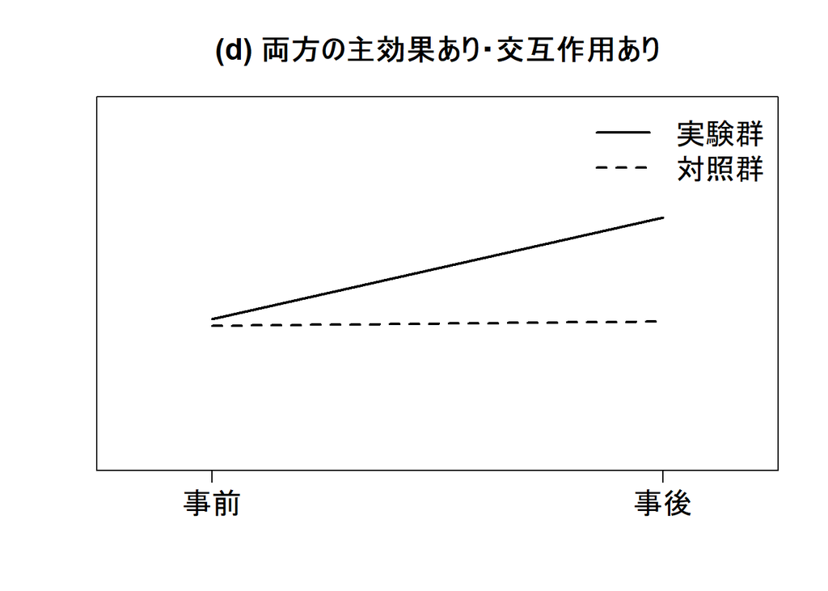

### 分散分析の結果

```
##
## Univariate Type II Repeated-Measures ANOVA Assuming Sphericity
##
##                Sum Sq num Df Error SS den Df F value    Pr(>F)
## (Intercept)   1306220      1    27808    198 9300.65 < 2.2e-16 ***
## group           16564      1    27808    198  117.94 < 2.2e-16 ***
## prepost         14908      1    12500    198  236.14 < 2.2e-16 ***
## group:prepost   12701      1    12500    198  201.18 < 2.2e-16 ***
## ---
## Signif. codes:  0 '***' 0.001 '**' 0.01 '*' 0.05 '.' 0.1 ' ' 1
```